# House Price Prediction - Nextel

Rafael Bicudo Rosa

2018/09/28

## Business Case - Nextel

The goal of this project is to investigate the features involved in the determination of the houses’ prices and develop the best price modeling algorithm.

## Stage 1 - Loading the Data

We start our approach by looking at our data, its characteristics and other primary informations.

```r
# Carrehando pacote necessario
library(dplyr)
# Abertura do df
houses <- read.csv('house_sales.csv')

## Basicas
summary(houses)
```

```
##      price            num_bed          num_bath       size_house
##  Min.   :  78000   Min.   : 0.000   Min.   :0.000   Min.   :  290
##  1st Qu.: 321838   1st Qu.: 3.000   1st Qu.:1.750   1st Qu.: 1430
##  Median : 450000   Median : 3.000   Median :2.250   Median : 1920
##  Mean   : 542362   Mean   : 3.373   Mean   :2.119   Mean   : 2084
##  3rd Qu.: 648000   3rd Qu.: 4.000   3rd Qu.:2.500   3rd Qu.: 2560
##  Max.   :7700000   Max.   :33.000   Max.   :8.000   Max.   :13540
##     size_lot         num_floors    is_waterfront        condition
##  Min.   :    520   Min.   :1.000   Min.   :0.000000   Min.   :1.000
##  1st Qu.:   5050   1st Qu.:1.000   1st Qu.:0.000000   1st Qu.:3.000
##  Median :   7600   Median :1.500   Median :0.000000   Median :3.000
##  Mean   :  15036   Mean   :1.495   Mean   :0.007643   Mean   :3.412
##  3rd Qu.:  10625   3rd Qu.:2.000   3rd Qu.:0.000000   3rd Qu.:4.000
##  Max.   :1651359   Max.   :3.500   Max.   :1.000000   Max.   :5.000
##  size_basement      year_built   renovation_date        zip
##  Min.   :   0.0   Min.   :1900   Min.   :   0.00   Min.   :98001
##  1st Qu.:   0.0   1st Qu.:1952   1st Qu.:   0.00   1st Qu.:98033
##  Median :   0.0   Median :1975   Median :   0.00   Median :98065
##  Mean   : 293.6   Mean   :1971   Mean   :  85.14   Mean   :98078
##  3rd Qu.: 570.0   3rd Qu.:1997   3rd Qu.:   0.00   3rd Qu.:98118
##  Max.   :4820.0   Max.   :2015   Max.   :2015.00   Max.   :98199
##     latitude       longitude      avg_size_neighbor_houses
##  Min.   :47.16   Min.   :-122.5   Min.   : 399
##  1st Qu.:47.47   1st Qu.:-122.3   1st Qu.:1490
##  Median :47.57   Median :-122.2   Median :1840
##  Mean   :47.56   Mean   :-122.2   Mean   :1988
##  3rd Qu.:47.68   3rd Qu.:-122.1   3rd Qu.:2370
##  Max.   :47.78   Max.   :-121.3   Max.   :6110
##  avg_size_neighbor_lot
##  Min.   :   651
##  1st Qu.:  5100
##  Median :  7611
##  Mean   : 12572
##  3rd Qu.: 10050
##  Max.   :858132
```

```r
sapply(houses, function(x) length(unique(x)))
```

```
##                    price                  num_bed                 num_bath
##                     3670                       12                       30
##               size_house                 size_lot               num_floors
##                      956                     8807                        6
##            is_waterfront                condition            size_basement
##                        2                        5                      283
##               year_built          renovation_date                      zip
##                      116                       68                       70
##                 latitude                longitude avg_size_neighbor_houses
##                    18324                    18287                      734
##    avg_size_neighbor_lot
##                     7865
```

```r
glimpse(houses)
```

```
## Observations: 18,448
## Variables: 16
## $ price                    <int> 221900, 538000, 180000, 604000, 51000...
## $ num_bed                  <int> 3, 3, 2, 4, 3, 4, 3, 3, 3, 3, 2, 3, 5...
## $ num_bath                 <dbl> 1.00, 2.25, 1.00, 3.00, 2.00, 4.50, 2...
## $ size_house               <int> 1180, 2570, 770, 1960, 1680, 5420, 17...
## $ size_lot                 <int> 5650, 7242, 10000, 5000, 8080, 101930...
## $ num_floors               <dbl> 1.0, 2.0, 1.0, 1.0, 1.0, 1.0, 2.0, 1....
## $ is_waterfront            <int> 0, 0, 0, 0, 0, 0, 0, 0, 0, 0, 0, 0, 0...
## $ condition                <int> 3, 3, 3, 5, 3, 3, 3, 3, 3, 3, 4, 4, 3...
## $ size_basement            <int> 0, 400, 0, 910, 0, 1530, 0, 730, 0, 1...
## $ year_built               <int> 1955, 1951, 1933, 1965, 1987, 2001, 1...
## $ renovation_date          <int> 0, 1991, 0, 0, 0, 0, 0, 0, 0, 0, 0, 0...
## $ zip                      <int> 98178, 98125, 98028, 98136, 98074, 98...
## $ latitude                 <dbl> 47.51123, 47.72102, 47.73793, 47.5208...
## $ longitude                <dbl> -122.2568, -122.3189, -122.2332, -122...
## $ avg_size_neighbor_houses <int> 1340, 1690, 2720, 1360, 1800, 4760, 2...
## $ avg_size_neighbor_lot    <int> 5650, 7639, 8062, 5000, 7503, 101930,...
```

The data looks like a bunch of features relationated to our main goal, very clean and without missing data, so it’s okay to proceed to our next step in the analysis.

## Stage 2 - Exploratory Data Analysis

The first thing to look is the geographic distribution of our data. To get this, I’ll use the an interactive plot from the package ‘leaflet’. It´s possible to see that the data is very close to each other.

```r
## Visualizacao interativa
library(leaflet)

leaflet(data = houses) %>% addTiles() %>%
  addMarkers(~longitude, ~latitude, popup = ~as.character(price),
             clusterOptions = markerClusterOptions()
  )
```

[interactive chart not shown]

Right next, we’ll look through out the joint distribution of our numeric data in relation to the target, and the barplots of the categoricals. As we can se bellow, most part of our data is correlated in some way to our target, but with some interesting outliers (like ‘num_bed’ where we have a house with 33). In a deeper analysis, would worth to investigate better the origin of the data to understand these outliers.

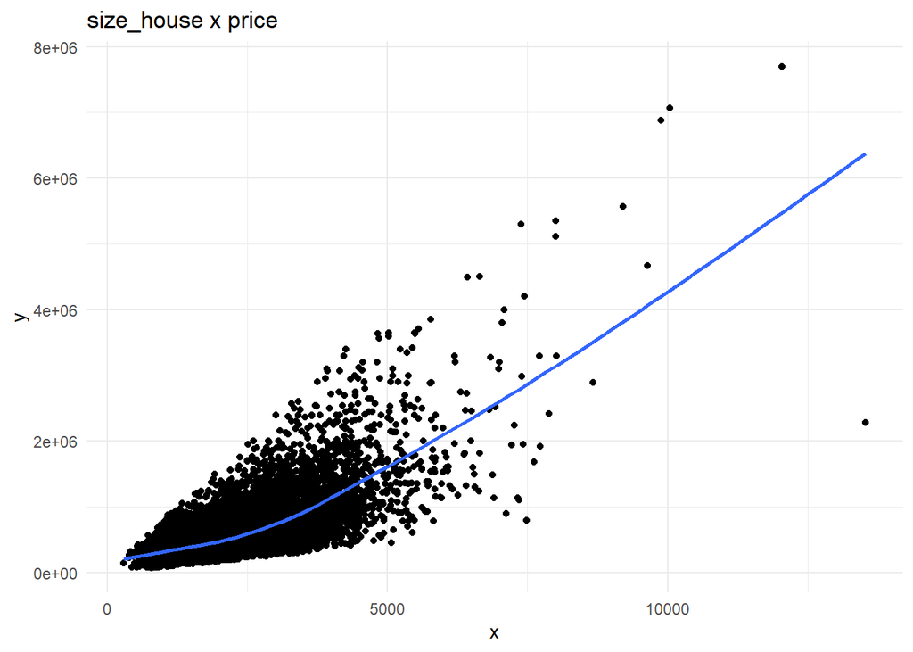

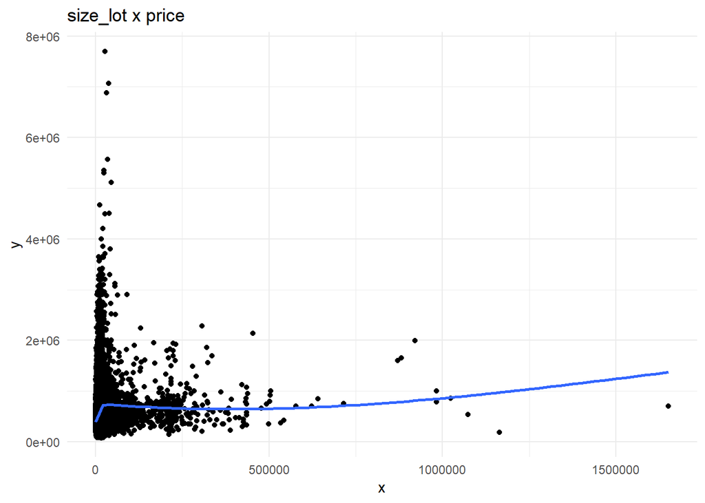

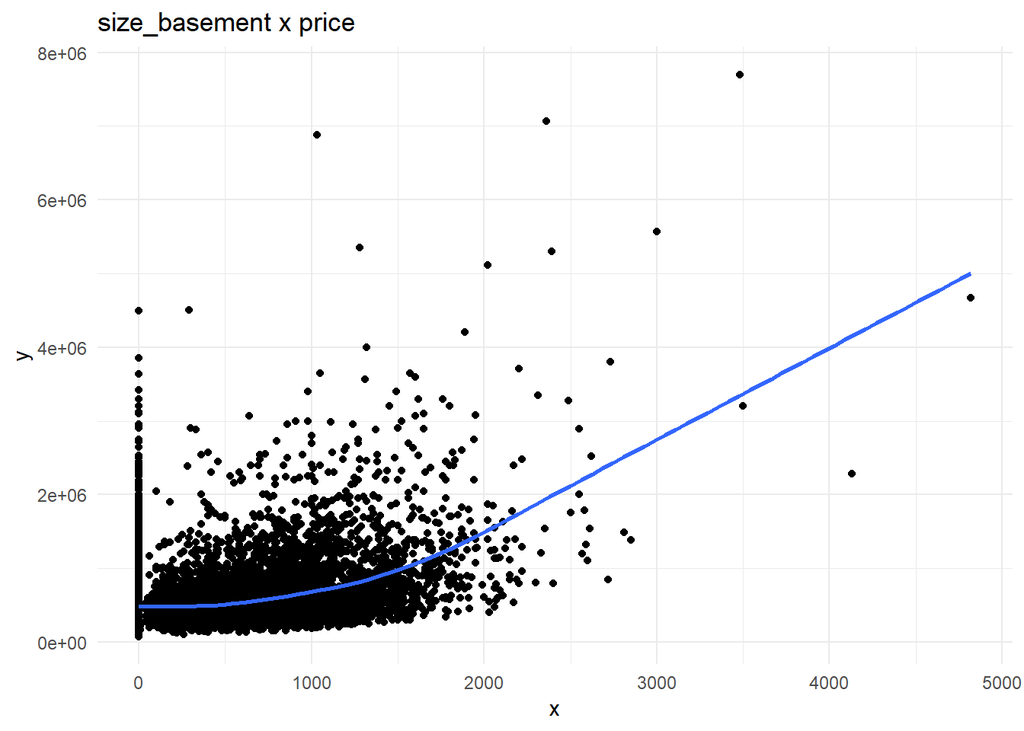

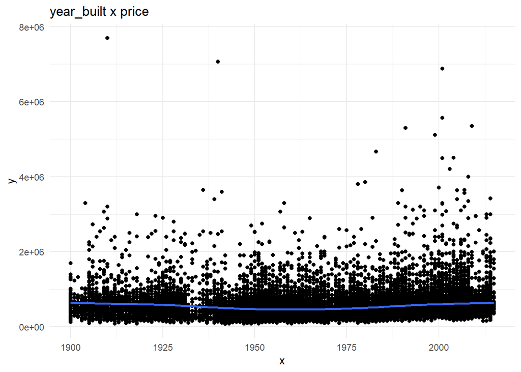

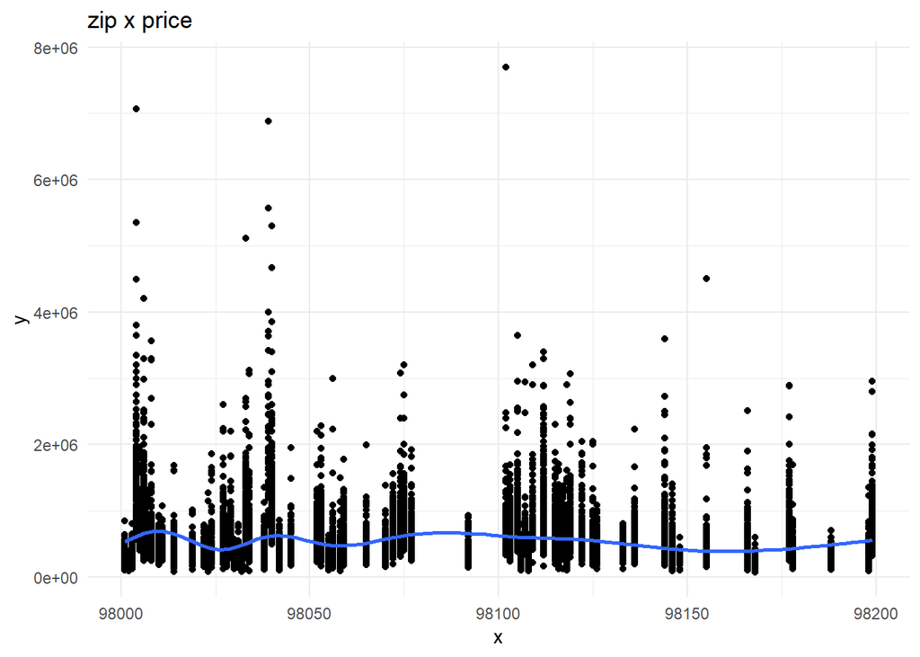

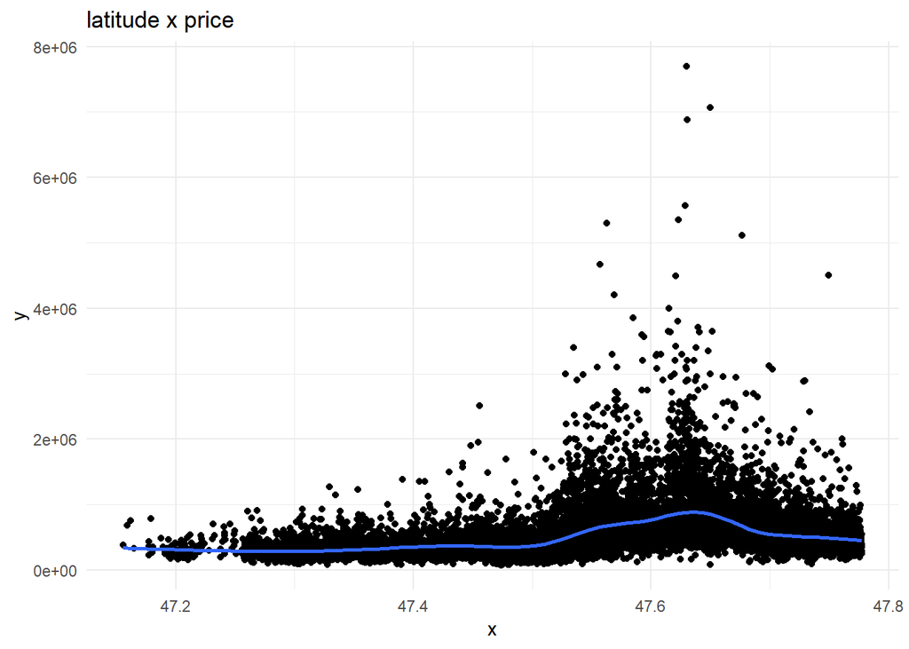

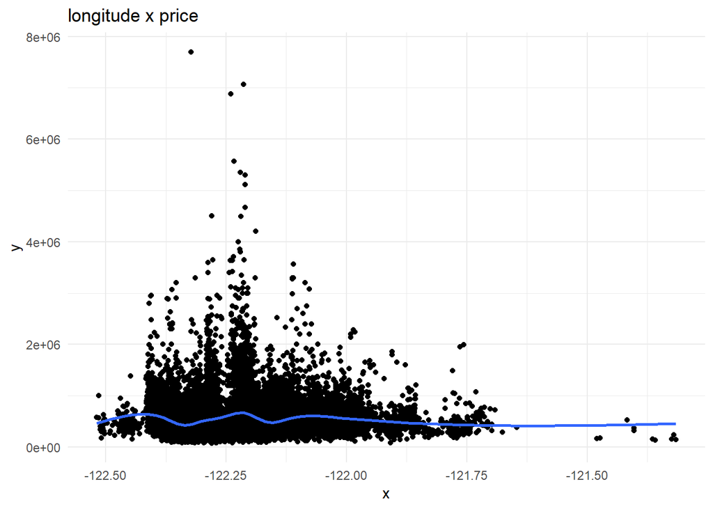

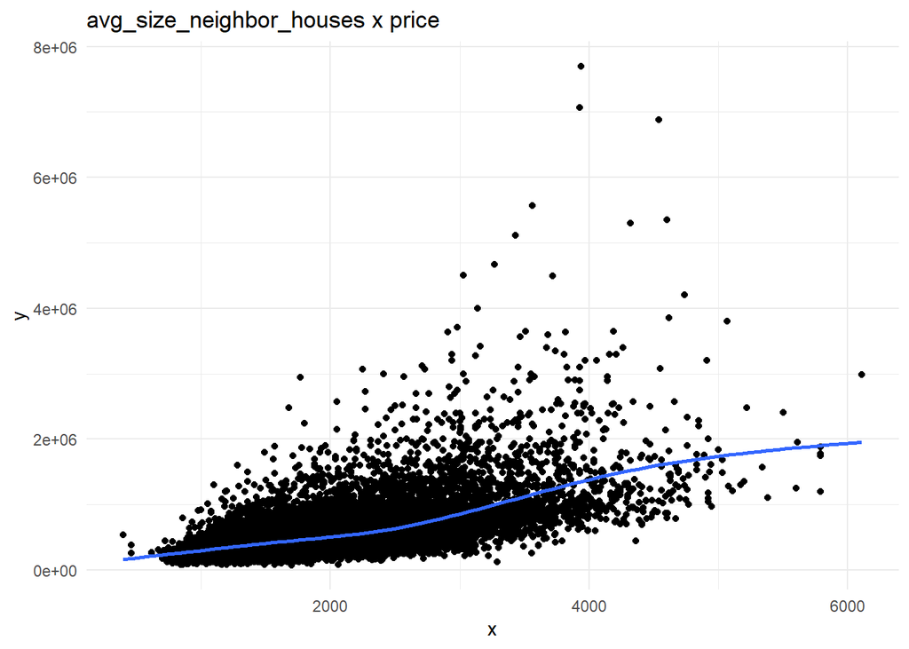

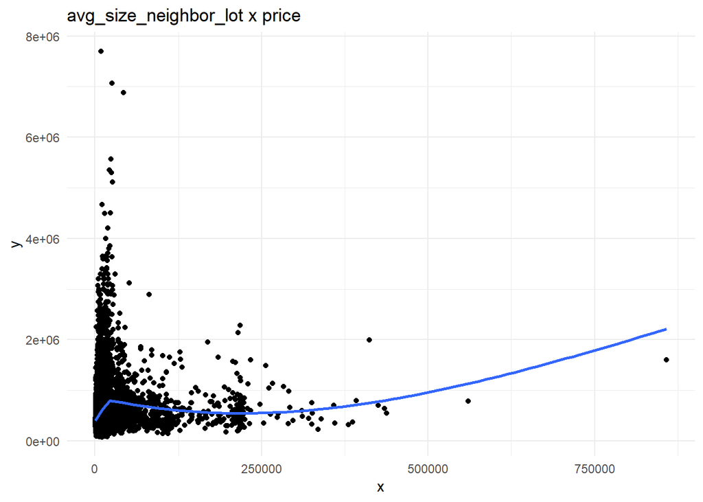

```r
# Pacote
library(ggplot2)

# visualizacao das variaveis continuas
target <- 'price'
categorical <- c('num_bed', 'num_bath', 'num_floors', 'is_waterfront', 'condition', 'renovation_date')
numeric <- setdiff(names(houses), c(target, categorical))

plots_num <- list()
for (var in numeric) {
  plots_num[[var]] <- ggplot(houses, aes_string(houses[[var]], houses[['price']])) +
    geom_point() +
    geom_smooth(se = F) +
    ggtitle(paste(var, 'x price')) +
    theme_minimal()
  print(plots_num[[var]])
}
```

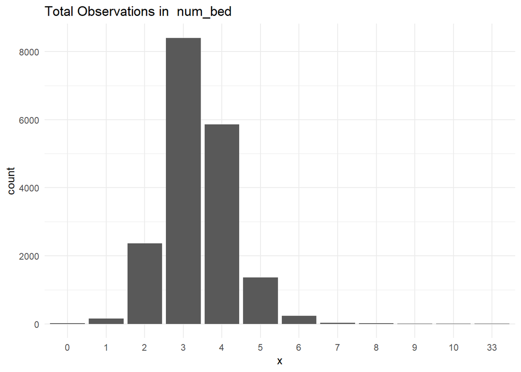

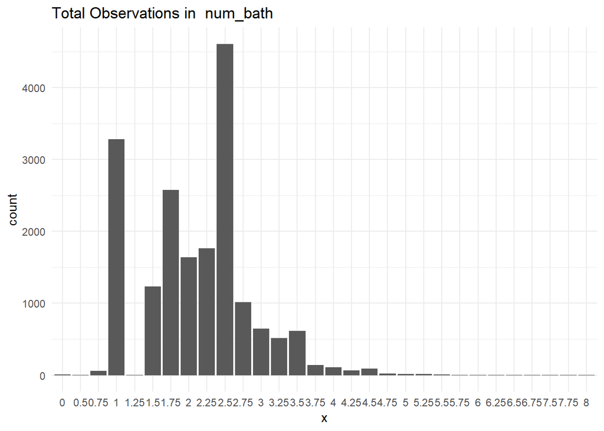

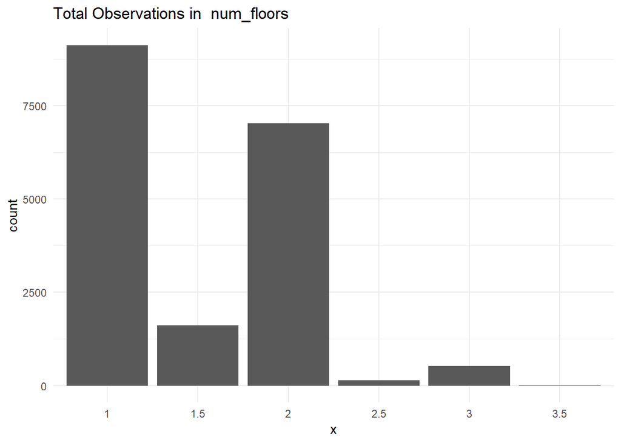

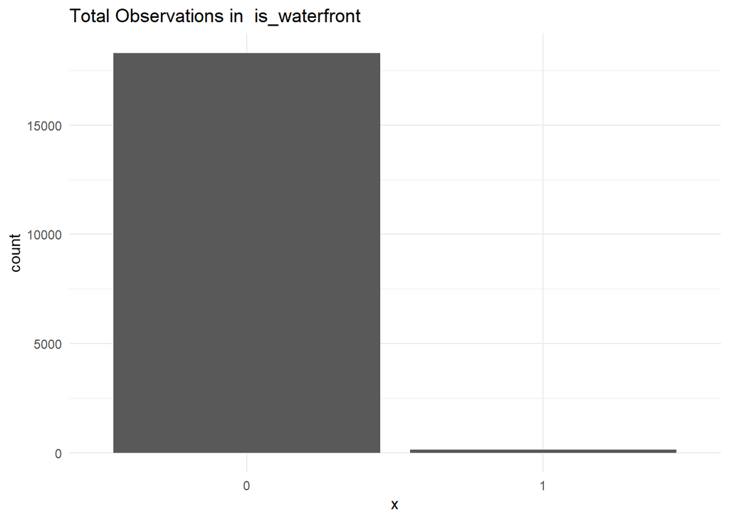

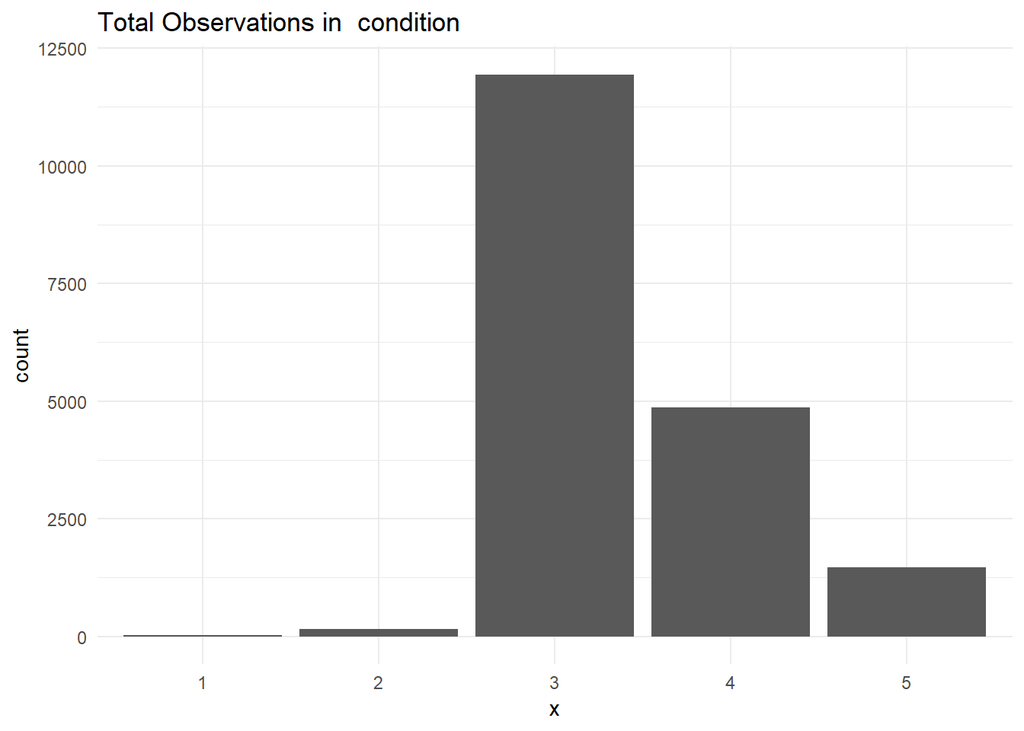

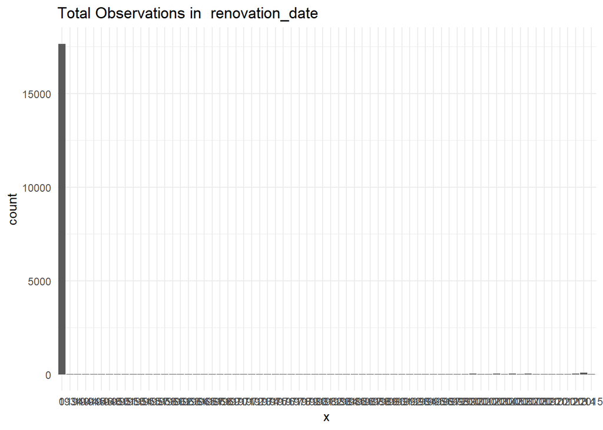

```r
plots_num = list()
# features que mereceriam clusterização ou pca: year_built, (lat x long), zip. Demais possuem relações n lineares

# visualizacao das variaveis categoricas

plots_cat <- list()
for (var in categorical) {
  plots_cat[[var]] <- ggplot(houses, aes_string(x = as.factor(houses[[var]]))) +
    geom_bar(stat = 'count') +
    ggtitle(paste('Total Observations in ',var)) +
    theme_minimal()
  print(plots_cat[[var]])
}
```

```r
plots_cat = list()
```

## Stage 3 - Baseline Model

Before we make any transformation in our data, I will proceed to baseline models to use as benchmark of our work using 2 algorithm: a lm and a xgboost. The First is the most basic for regression problemns and the second was choose for being one of the most sofisticated of the atuality. All the controls and parameters will be first placed for the reproducability of the next models.The package choosed was the MLR.

```r
# Pacote
library(mlr)
set.seed(1994)

# modelo padrão linear
regr.lm <- makeLearner('regr.lm')

# Criação do modelo simples
xgb_model <- makeLearner("regr.xgboost")
# Grid de alguns parâmetros
xgb_params <- makeParamSet(
  # The number of trees in the model (each one built sequentially)
  makeIntegerParam("nrounds", lower = 100, upper = 500),
  # number of splits in each tree
  makeIntegerParam("max_depth", lower = 1, upper = 10),
  # "shrinkage" - prevents overfitting
  makeNumericParam("eta", lower = .1, upper = .5),
  # L2 regularization - prevents overfitting
  makeNumericParam("lambda", lower = -1, upper = 0, trafo = function(x) 10^x)
)

# Controle da tunagem randômica
control <- makeTuneControlRandom(maxit = 3) # quantas iterações o modelo aleatório de seleção fará

# Plano de resampling
resample_desc <- makeResampleDesc("CV", iters = 5)
```

With all the controls defined, we can proceed to the hold out separation, model training and performance evaluation. The metrics used were rmse and rsq.

```r
## Baseline

# Criação do Task para Regressão (objeto usado nas operações do pacote)
baseline_task <- makeRegrTask(id = 'Baseline', data = houses, target = 'price')

# train test split (holdout é o método de resample de separar em train/test)
holdout <- makeResampleInstance('Holdout', baseline_task)
base_train <- subsetTask(baseline_task, holdout$train.inds[[1]])
base_test <- subsetTask(baseline_task, holdout$test.inds[[1]])

# treinamento modelo
base_lm <- train(regr.lm, base_train)

## XGBoost

# tunador dos hiper parâmetros
tuned_params_base <- tuneParams(
  learner = xgb_model,
  task = base_train,
  resampling = resample_desc,
  measures = rmse,       # R-Squared performance measure, this can be changed to one or many
  par.set = xgb_params,
  control = control
)
```

```
## [Tune] Started tuning learner regr.xgboost for parameter set:
```

```
##              Type len Def     Constr Req Tunable Trafo
## nrounds   integer   -   - 100 to 500   -    TRUE     -
## max_depth integer   -   -    1 to 10   -    TRUE     -
## eta       numeric   -   - 0.1 to 0.5   -    TRUE     -
## lambda    numeric   -   -    -1 to 0   -    TRUE     Y
```

```
## With control class: TuneControlRandom
```

```
## Imputation value: Inf
```

```
## [Tune-x] 1: nrounds=350; max_depth=7; eta=0.363; lambda=0.104
```

```
## [Tune-y] 1: rmse.test.rmse=141392.8846413; time: 0.2 min
```

```
## [Tune-x] 2: nrounds=224; max_depth=5; eta=0.42; lambda=0.336
```

```
## [Tune-y] 2: rmse.test.rmse=136447.5969390; time: 0.1 min
```

```
## [Tune-x] 3: nrounds=257; max_depth=2; eta=0.477; lambda=0.399
```

```
## [Tune-y] 3: rmse.test.rmse=141469.7455336; time: 0.0 min
```

```
## [Tune] Result: nrounds=224; max_depth=5; eta=0.42; lambda=0.336 : rmse.test.rmse=136447.5969390
```

```r
# Modelo tunado
xgb_tuned_base <- setHyperPars(
  learner = xgb_model,
  par.vals = tuned_params_base$x
)

# Verificação da performance do modelo tunado usando as validações cruzadas usadas para tunagem
resample(xgb_tuned_base,base_train,resample_desc,measures = list(rmse, rsq))
```

```
## Resampling: cross-validation
```

```
## Measures:             rmse      rsq
```

```
## [Resample] iter 1:    121665.63407770.8808065
```

```
## [Resample] iter 2:    128409.80775840.8701808
```

```
## [Resample] iter 3:    136351.28180940.8518187
```

```
## [Resample] iter 4:    160822.91940860.8472235
```

```
## [Resample] iter 5:    143651.16573020.8395942
```

```
## Aggregated Result: rmse.test.rmse=138840.1571001,rsq.test.mean=0.8579248
```

```
## Resample Result
## Task: Baseline
## Learner: regr.xgboost
## Aggr perf: rmse.test.rmse=138840.1571001,rsq.test.mean=0.8579248
## Runtime: 5.42629
```

```r
# pela grande diferença entre as cvs, o modelo está com bastante overffiting

# Treinamento
base_XGBoost <- train(xgb_tuned_base, base_train)

## Performance - Baseline

# predição nos dados de teste
base_pred_lm <- predict(base_lm, base_test)
performance(base_pred_lm, measures = list(rmse, rsq))
```

```
##         rmse          rsq
## 2.203247e+05 6.651386e-01
```

```r
base_pred_xgb <- predict(base_XGBoost, base_test)
performance(base_pred_xgb, measures = list(rmse, rsq))
```

```
##         rmse          rsq
## 1.531862e+05 8.381256e-01
```

## Stage 4 - Feature Engineering

Trying to improve our model efficiency, we’ll start some transformation on the variables to avoid overfitting and diminishing the rmse of the test data. With the latitude and longitude features, I’ll use kmean clustering to improve the gain of information using a wss score validation. In the case of the categorical features, I’ll agroup the low represented classes and use a one hot encoding approach to use them factors in the model. For last, I’ll remove the near zero variance features.

```r
## Featrue Engineering

## Features Geográficas
geo <- houses %>% select(price, latitude, longitude)

# Initialize total within sum of squares error: wss
wss <- 0

# For 1 to 15 cluster centers
for (i in 1:15) {
  km.out <- kmeans(geo %>% select(-c(price)), centers = i, nstart = 50)
  # Save total within sum of squares to wss variable
  wss[i] <- km.out$tot.withinss
}
```

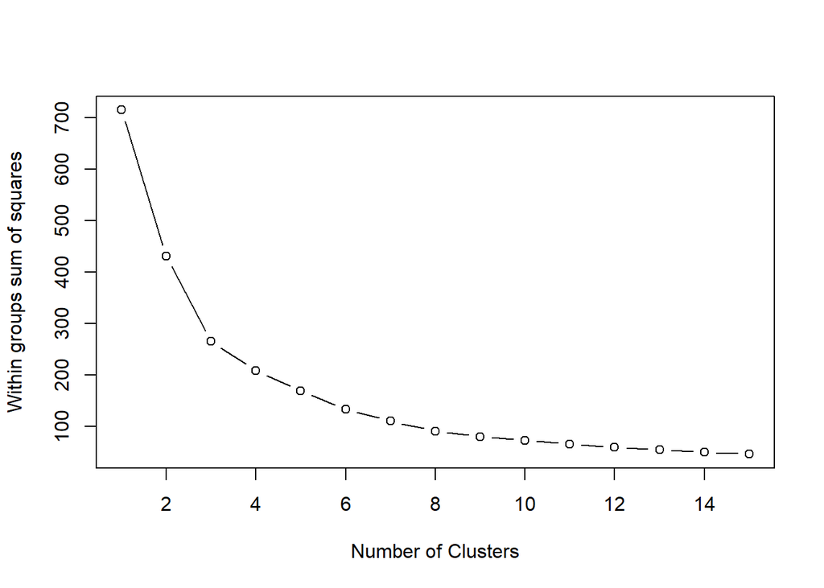

```r
# Plot total within sum of squares vs. number of clusters
plot(1:15, wss, type = "b",
     xlab = "Number of Clusters",
     ylab = "Within groups sum of squares")
```

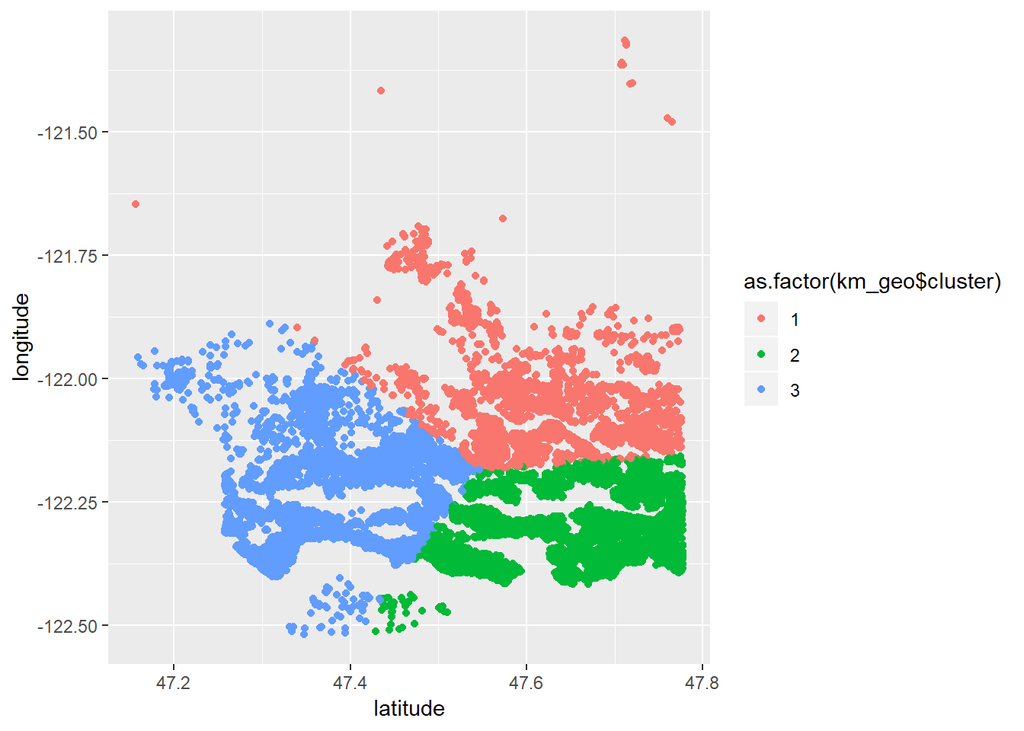

```r
# Set k equal to the number of clusters corresponding to the elbow location
k_latLon <- 3
km_geo <- kmeans(geo %>% select(-price), centers = k_latLon, nstart = 50)
ggplot(geo, aes(latitude, longitude, col = as.factor(km_geo$cluster))) +
  geom_point()
```

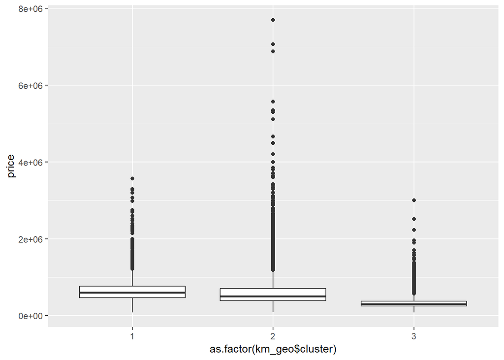

```r
ggplot(geo, aes(x = as.factor(km_geo$cluster), price)) +
  geom_boxplot()
```

```r
latLon_cluster <- km_geo$cluster

categoricalCoerc <- houses %>%
  select(c(num_bed, num_bath, num_floors, condition, renovation_date)) %>%
  mutate(num_bed_c = ifelse(num_bed < 3,
                            2, ifelse(num_bed > 4, 5, num_bed)),
         num_bath_c = ifelse(num_bath < 1.5,
                             1.25, ifelse(num_bath > 3.5, 3.75, num_bath)),
         num_floors_c = ifelse(num_floors > 2, 2.5, num_floors),
         condition_c = ifelse(condition < 3, 3, condition),
         renovation_date_c = ifelse(renovation_date == 0, 0, 1)) %>%
  select(-c(num_bed, num_bath, num_floors, condition, renovation_date))

# is_waterfront - baixíssima variância e impacto muito razoável no preço
summary(factor(houses$is_waterfront))
```

```
##     0     1
## 18307   141
```

```r
# Sumarização das novas Features
houses_nf <- cbind(houses, latLon_cluster, categoricalCoerc) %>%
  select(-c(latitude, longitude, num_bed, num_bath, num_floors, condition, renovation_date, is_waterfront))

## One hot Encoding

# factorização
houses_fact <- houses_nf %>%
  mutate_at(
    .vars = vars('zip', 'latLon_cluster','num_bed_c', 'num_bath_c', 'num_floors_c', 'condition_c',
                 'renovation_date_c'),
    .funs = funs(as.factor(.))
  )

# Sumarizando as colunas
summarizeColumns(houses_fact) %>%
  knitr::kable(digits = 2) # gerador de tabelas muito prático do knitr
```

| name | type | na | mean | disp | median | mad | min | max | nlevs |
| --- | --- | --- | --- | --- | --- | --- | --- | --- | --- |
| price | integer | 0 | 542362.37 | 372013.52 | 450000.0 | 222390.00 | 78000 | 7700000 | 0 |
| size_house | integer | 0 | 2083.94 | 921.42 | 1920.0 | 815.43 | 290 | 13540 | 0 |
| size_lot | integer | 0 | 15036.02 | 41814.55 | 7600.5 | 3855.50 | 520 | 1651359 | 0 |
| size_basement | integer | 0 | 293.57 | 443.61 | 0.0 | 0.00 | 0 | 4820 | 0 |
| year_built | integer | 0 | 1971.00 | 29.36 | 1975.0 | 34.10 | 1900 | 2015 | 0 |
| zip | factor | 0 | NA | 0.97 | NA | NA | 45 | 512 | 70 |
| avg_size_neighbor_houses | integer | 0 | 1988.31 | 686.17 | 1840.0 | 607.87 | 399 | 6110 | 0 |
| avg_size_neighbor_lot | integer | 0 | 12571.60 | 26329.26 | 7611.0 | 3693.16 | 651 | 858132 | 0 |
| latLon_cluster | factor | 0 | NA | 0.53 | NA | NA | 4253 | 8612 | 3 |
| num_bed_c | factor | 0 | NA | 0.54 | NA | NA | 1655 | 8403 | 4 |
| num_bath_c | factor | 0 | NA | 0.75 | NA | NA | 484 | 4607 | 11 |
| num_floors_c | factor | 0 | NA | 0.51 | NA | NA | 677 | 9124 | 4 |
| condition_c | factor | 0 | NA | 0.34 | NA | NA | 1466 | 12117 | 3 |
| renovation_date_c | factor | 0 | NA | 0.04 | NA | NA | 787 | 17661 | 2 |

```r
# Normalização
houses_norm <- normalizeFeatures(houses_fact, target = "price")

# One hot encoding
houses_ohe <- createDummyFeatures(
  houses_norm, target = "price",
  cols = c(
    'zip', 'latLon_cluster','num_bed_c', 'num_bath_c', 'num_floors_c', 'condition_c',
    'renovation_date_c'
  )
)
```

Now, I’ll use this new dataset to evaluat the gain (or not) of performance. As we can see right next, incredibly, the model got worse when using the xgboost. Probably because of the capacity of interpreating non linear data, its boosting method, and the low amount of data, the generalization lead to a underfitting. At the end, we can see a plot of the most importante features for the determination of the predicted value on the best model (the first one).

```r
## Feature engineering

# Criação do Task para Regressão (objeto usado nas operações do pacote) FE
fe_task <- makeRegrTask(id = 'Feature Engineering', data = houses_ohe, target = 'price')

# Separação do hold out FE usando os mesmo índices usados no baseline
fe_train <- subsetTask(fe_task, holdout$train.inds[[1]])
fe_test <- subsetTask(fe_task, holdout$test.inds[[1]])

# lm FE
fe_lm <- train(regr.lm, fe_train)

# tunador dos hiper parâmetros FE
tuned_params_fe <- tuneParams(
  learner = xgb_model,
  task = fe_train,
  resampling = resample_desc,
  measures = rmse,
  par.set = xgb_params,
  control = control
)
```

```
## [Tune] Started tuning learner regr.xgboost for parameter set:
```

```
##              Type len Def     Constr Req Tunable Trafo
## nrounds   integer   -   - 100 to 500   -    TRUE     -
## max_depth integer   -   -    1 to 10   -    TRUE     -
## eta       numeric   -   - 0.1 to 0.5   -    TRUE     -
## lambda    numeric   -   -    -1 to 0   -    TRUE     Y
```

```
## With control class: TuneControlRandom
```

```
## Imputation value: Inf
```

```
## [Tune-x] 1: nrounds=365; max_depth=7; eta=0.345; lambda=0.949
```

```
## [Tune-y] 1: rmse.test.rmse=165933.9776742; time: 0.5 min
```

```
## [Tune-x] 2: nrounds=419; max_depth=7; eta=0.471; lambda=0.239
```

```
## [Tune-y] 2: rmse.test.rmse=169955.5873893; time: 0.7 min
```

```
## [Tune-x] 3: nrounds=416; max_depth=9; eta=0.136; lambda=0.315
```

```
## [Tune-y] 3: rmse.test.rmse=162956.2999533; time: 0.9 min
```

```
## [Tune] Result: nrounds=416; max_depth=9; eta=0.136; lambda=0.315 : rmse.test.rmse=162956.2999533
```

```r
# Modelo tunado FE
xgb_tuned_fe <- setHyperPars(
  learner = xgb_model,
  par.vals = tuned_params_fe$x
)

# Verificação da performance do modelo tunado usando as validações cruzadas usadas para tunagem
resample(xgb_tuned_fe,fe_train,resample_desc,measures = list(rmse, rsq))
```

```
## Resampling: cross-validation
```

```
## Measures:             rmse      rsq
```

```
## [Resample] iter 1:    173679.99097880.8005897
```

```
## [Resample] iter 2:    172162.73864550.8154329
```

```
## [Resample] iter 3:    172678.33934540.7457438
```

```
## [Resample] iter 4:    162182.78919630.8024064
```

```
## [Resample] iter 5:    159188.55464550.7752523
```

```
## Aggregated Result: rmse.test.rmse=168087.3640492,rsq.test.mean=0.7878850
```

```
## Resample Result
## Task: Feature Engineering
## Learner: regr.xgboost
## Aggr perf: rmse.test.rmse=168087.3640492,rsq.test.mean=0.7878850
## Runtime: 53.0969
```

```r
# cvs bem mais similares, indicando uma generalização mais acurada

# Treinamento
fe_XGBoost <- train(xgb_tuned_fe, fe_train)

## Performance - FE

# predição nos dados de teste
fe_pred_lm <- predict(fe_lm, fe_test)
performance(fe_pred_lm, measures = list(rmse, rsq))
```

```
##         rmse          rsq
## 1.875161e+05 7.574420e-01
```

```r
fe_pred_xgb <- predict(fe_XGBoost, fe_test)
performance(fe_pred_xgb, measures = list(rmse, rsq))
```

```
##         rmse          rsq
## 1.596013e+05 8.242838e-01
```

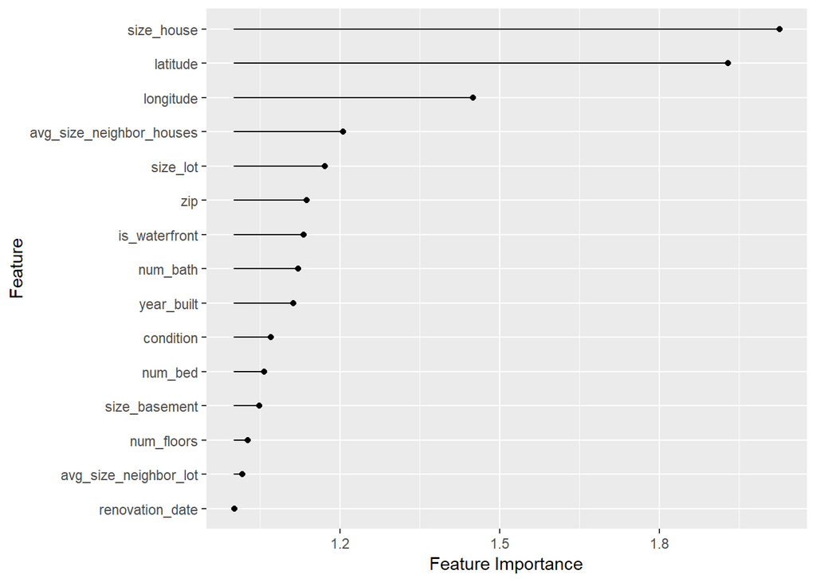

```r
# Plotagem das features mais importantes
library(iml)

# usando Predictor$new() para criar um plot das features mais importantes
X = getTaskData(base_test)[getTaskFeatureNames(base_test)]
base_predictor = Predictor$new(base_XGBoost, data = X, y = getTaskData(base_test)['price'])
base_imp = FeatureImp$new(base_predictor, loss = "rmse")
plot(base_imp)
```